# Analysis of NOAA Storm Data to Determine Impact on Population Health and Economic Consequences

## Synopsis

The goal of this report is to look at the various event types of NOAA Storm Data and determine which ones have greatest harmful impact to population health and economic consequences. Events are considered across the United States paying no attention to location or time of the year the events occurred. Therefore, focus is on four key categories related to event type: fatalities, injuries, property damage cost, and crop damage cost. Aggregate sums of each are computed to determine the top ten worst events in each category.

## Data Processing

Data and documentation for this report were downloaded from the course project website. The URLs are listed below. In addition, information from the [NOAA Storm Data](https://www.ncdc.noaa.gov/stormevents/) website was used in determining how to process data; specifically for the calculation of property and crop damage.

- [Data](https://d396qusza40orc.cloudfront.net/repdata%2Fdata%2FStormData.csv.bz2)
- [Storm Data Documentation](https://d396qusza40orc.cloudfront.net/repdata%2Fpeer2_doc%2Fpd01016005curr.pdf)
- [Storm Evens FAQ](https://d396qusza40orc.cloudfront.net/repdata%2Fpeer2_doc%2FNCDC%20Storm%20Events-FAQ%20Page.pdf)

### Initialization

Before data processing begins, we load needed libraries, set working directory and read in the data.

```r
# load libraries
library(ggplot2)
library(knitr)

# set working directory
#   change to match your computer when running this script
setwd("~/Documents/courses/repdata/RepData_PeerAssessment2")

# read in the data file
noaa <- read.csv("data/repdata_data_StormData.csv.bz2",
                 sep = ",",
                 strip.white = TRUE,
                 stringsAsFactors = FALSE)
```

### Processing

Since focus of this report is limited to harmful impact to population health and economic consequences across the United States, only a subset of the data is needed. The following data columns are use:

- **EVTYPE:** The type of event. Examples: Tornado, Wind, Snow.
- **FATALITIES:** Number of deaths directly related to the event.
- **INJURIES:** Number of injuries directly related to the event.
- **PROPDMG:** Base amount of property damage.
- **PROPDMGEXP:** Base multiplier for property damage. (0-1: 1; H: 100; K: 1,000; M: 1,000,000; B: 1,000,000,000)
- **CROPDMG:** Base amount of crop damage.
- **CROPDMGEXP:** Base multiplier for crop damage. (0-1: 1; H: 100; K: 1,000; M: 1,000,000; B: 1,000,000,000)

```r
# this R code block is cached for future renders

# only include columns relevant to our questions
noaa <- subset(noaa,
               select = c(EVTYPE,FATALITIES,INJURIES,
                          PROPDMG,PROPDMGEXP,CROPDMG,CROPDMGEXP))

# up-shift PROPDMGEXP and CROPDMGEXP columns
noaa$PROPDMGEXP <- toupper(noaa$PROPDMGEXP)
noaa$CROPDMGEXP <- toupper(noaa$CROPDMGEXP)

# add columns for property and crop damage totals
noaa$TOTPROPDMG <- 0
noaa$TOTCROPDMG <- 0

numbers <- as.character(1:9)

# calculate property damage totals
noaa$TOTPROPDMG[which(noaa$PROPDMGEXP %in% numbers)] <-
  noaa$PROPDMG[which(noaa$PROPDMGEXP %in% numbers)] * 1
noaa$TOTPROPDMG[which(noaa$PROPDMGEXP == "H")] <-
  noaa$PROPDMG[which(noaa$PROPDMGEXP == "H")] * 100
noaa$TOTPROPDMG[which(noaa$PROPDMGEXP == "K")] <-
  noaa$PROPDMG[which(noaa$PROPDMGEXP == "K")] * 1000
noaa$TOTPROPDMG[which(noaa$PROPDMGEXP == "M")] <-
  noaa$PROPDMG[which(noaa$PROPDMGEXP == "M")] * 1000000
noaa$TOTPROPDMG[which(noaa$PROPDMGEXP == "B")] <-
  noaa$PROPDMG[which(noaa$PROPDMGEXP == "B")] * 1000000000

# calculate crop damage totals
noaa$TOTCROPDMG[which(noaa$CROPDMGEXP %in% numbers)] <-
  noaa$CROPDMG[which(noaa$CROPDMGEXP %in% numbers)] * 1
noaa$TOTCROPDMG[which(noaa$CROPDMGEXP == "H")] <-
  noaa$CROPDMG[which(noaa$CROPDMGEXP == "H")] * 100
noaa$TOTCROPDMG[which(noaa$CROPDMGEXP == "K")] <-
  noaa$CROPDMG[which(noaa$CROPDMGEXP == "K")] * 1000
noaa$TOTCROPDMG[which(noaa$CROPDMGEXP == "M")] <-
  noaa$CROPDMG[which(noaa$CROPDMGEXP == "M")] * 1000000
noaa$TOTCROPDMG[which(noaa$CROPDMGEXP == "B")] <-
  noaa$CROPDMG[which(noaa$CROPDMGEXP == "B")] * 1000000000
```

## Results

### Events affecting population health

#### Injuries

A graph of the top ten most harmful events to population based on number of injuries shows that tornadoes cause the most injuries. No other events even come close.

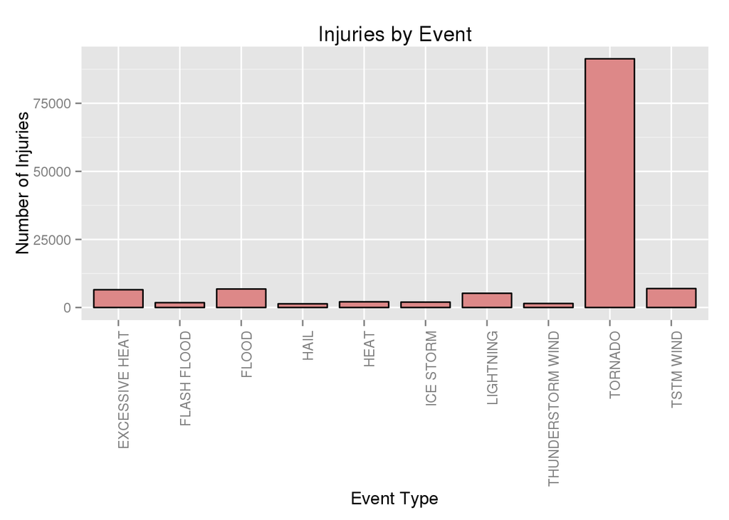

```r
# injuries by EVTYPE
injuries <- aggregate(INJURIES ~ EVTYPE, noaa, sum)
top10injuries <- head(injuries[with(injuries, order(-INJURIES)), ], n=10L)

ggplot(data=top10injuries, aes(x=EVTYPE, y=INJURIES)) +
  geom_bar(colour="black", fill="#DD8888", width=.8, stat="identity") +
  theme(axis.text.x = element_text(angle = 90, hjust = 1)) +
  xlab("Event Type") +
  ylab("Number of Injuries") +
  ggtitle("Injuries by Event")
```

#### Fatalities

Similarly a graph of the top ten most harmful events to population based on number of fatalities shows that tornadoes too cause the most fatalities.

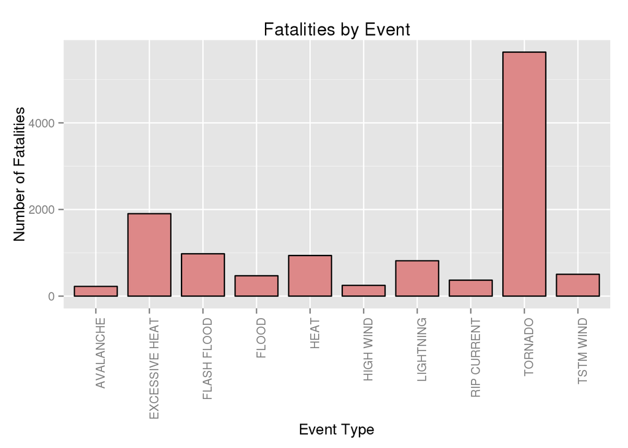

```r
# fatalities by EVTYPE
fatalities <- aggregate(FATALITIES ~ EVTYPE, noaa, sum)
top10fatalities <- head(fatalities[with(fatalities, order(-FATALITIES)), ], n=10L)

ggplot(data=top10fatalities, aes(x=EVTYPE, y=FATALITIES)) +
  geom_bar(colour="black", fill="#DD8888", width=.8, stat="identity") +
  theme(axis.text.x = element_text(angle = 90, hjust = 1)) +
  xlab("Event Type") +
  ylab("Number of Fatalities") +
  ggtitle("Fatalities by Event")
```

### Events affecting economic damage to property and crops

To determine the impact of economic damage to property and crops, the sum of damages for each event were calculated. The results are displayed as tables sorted descending by total damage in billion of dollars.

#### Property Damage

From the table it is clear that floods cause the most costly damage to property.

```r
# property damage by EVTYPE
totpropdmg <- aggregate(TOTPROPDMG ~ EVTYPE, noaa, sum)
# convert to billions for reporting purposes; sum get too large
totpropdmg$TOTPROPDMG <- round(totpropdmg$TOTPROPDMG/1000000000, digits=1)

kable(head(totpropdmg[with(totpropdmg, order(-TOTPROPDMG)), ], n=10L),
      row.name= FALSE, col.names = c("Event Type","Cost of Damage"),
      caption = "Property Damage in Billions of Dollars",
      format = "html",
      table.attr = "border=\"1\"")
```

Property Damage in Billions of Dollars

| Event Type | Cost of Damage |
| --- | --- |
| FLOOD | 144.7 |
| HURRICANE/TYPHOON | 69.3 |
| TORNADO | 56.9 |
| STORM SURGE | 43.3 |
| FLASH FLOOD | 16.1 |
| HAIL | 15.7 |
| HURRICANE | 11.9 |
| TROPICAL STORM | 7.7 |
| WINTER STORM | 6.7 |
| HIGH WIND | 5.3 |

#### Crop Damage

Drought is shown to cause the most costly damage to crops.

```r
# crop damage by EVTYPE
totcropdmg <- aggregate(TOTCROPDMG ~ EVTYPE, noaa, sum)
# convert to billions for reporting purposes; sum get too large
totcropdmg$TOTCROPDMG <- round(totcropdmg$TOTCROPDMG/1000000000, digits=1)

kable(head(totcropdmg[with(totcropdmg, order(-TOTCROPDMG)), ], n=10L),
      row.name= FALSE, col.names = c("Event Type","Cost of Damage"),
      caption = "Crop Damage in Billions of Dollars",
      format = "html",
      table.attr = "border=\"1\"")
```

Crop Damage in Billions of Dollars

| Event Type | Cost of Damage |
| --- | --- |
| DROUGHT | 14.0 |
| FLOOD | 5.7 |
| ICE STORM | 5.0 |
| RIVER FLOOD | 5.0 |
| HAIL | 3.0 |
| HURRICANE | 2.7 |
| HURRICANE/TYPHOON | 2.6 |
| FLASH FLOOD | 1.4 |
| EXTREME COLD | 1.3 |
| FROST/FREEZE | 1.1 |